# Truthiness Pilot Study

Truthiness is the belief that a statement is true based on intuition, without regard to evidence, logic, or facts. When individuals evaluate claims, they use both rational approaches to evaluating evidence and gut feelings about the overall trustworthiness of both the person making the claim and the claim itself. This decision making process has huge implications for the evaluation of evidence in a courtroom, as jurors are constantly asked to assess the truth of statements based on claims presented during trial, both with and without evidence. (Kellermann 2013)

The “truthiness effect” is present in situations in which individuals must rapidly evaluate the truth of a claim. In these situations, nonprobative or auxiliary information about the situation or stimulus causes individuals to more readily evaluate the claim as truthful. This effect may stem from semantic priming; that is, when provided with additional information which is not relevant to the claim but is related to the topic, the brain retrieves related information from memory and evaluates the total set of information (relevant and irrelevant) in order to establish the trustworthiness of the claim and claimant. (Newman et al. 2012) In addition, the ease of retrieval of information may be interpreted as relating to the percieved veracity of the claim, that is, priming the retrieval of related information may provide not only a greater quantity of information, but also decrease the effort required to locate information in long term memory.

This effect has been shown to exist in the following situations:

- The Alive/Dead status of familiar and unfamiliar celebrities. When pictures of the celebrities were provided along with a statement such as “Name is alive/dead”, participants were more likely to believe claims about unfamiliar celebrities. This effect was not tied to the credibility of the photos or the source of the additional information. (Newman et al. 2012)
- Statements of general trivia (“Macadamia nuts are in the same evolutionary family as peaches”) plus a picture related to the subject of the claim were more liekly to be believed (Newman et al. 2012) than similar claims with no accompanying photo

The truthiness bias persists over the course of several days; that is, even 2 days after being shown a claim and a peripherally related picture, participants are more likely to judge the claim as true than when shown a claim without a picture. (Fenn et al. 2013)

There have been some examinations of the effect of nonprobative images showing truthiness, falsiness, and nothingness in legal situations, but there is no consistent explanation of why this effect exists. (Kellermann 2013)

- Academic article was perceived as more reasonable when accompanied by an image of a brain, but not when accompanied by a bar chart (McCabe and Castel 2008)

Experimental Design Considerations:

- Order effects - the feeling of easy retrieval is driven by comparison against a standard, so prior trials may influence the perceived ease of information retrieval of future trials
- Stimuli quality - Images which are difficult to parse may bias subjects to judge claims more harshly
- Truthiness and falsiness effects disappear when participants experience only one condition (e.g. when they only see photos with claims, or when they never see photos with claims). Thus, these effects are formed by participant expectations.

## Pilot Study Options

### Plot-based Truthiness

Goal: Establish truthiness effect (or lack thereof) for statistical graphics

#### Experiment 1: Standard truthiness protocol

Generate a set of ~30 trivia questions which relate to numerical/plottable information

Participants are shown each claim in one of the following scenarios:

1. Text only
2. Picture related to the subject of the claim (nonprobative) + text
3. Picture unrelated to the claim + text
4. Graph related to the subject of the claim (nonprobative) + text
5. Graph unrelated to the subject of the claim + text
6. Graph related to the subject of the claim (probative) + text

Scenarios 1-3 are the classic truthiness protocol, where the claim is more likely to be believed in scenario 2, but scenarios 1 and 3 behave fairly similarly (e.g. participants ignore the unrelated picture).

Statement: The cobra is the largest snake in the world

Scenario 1

Scenario 2

Scenario 3

no image

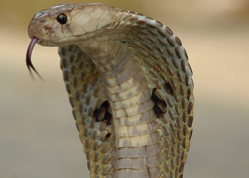

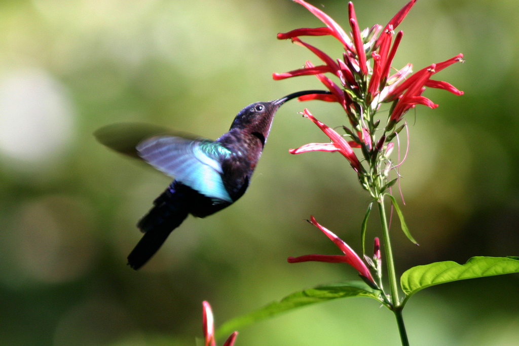

Scenario 4

Scenario 5

Scenario 6

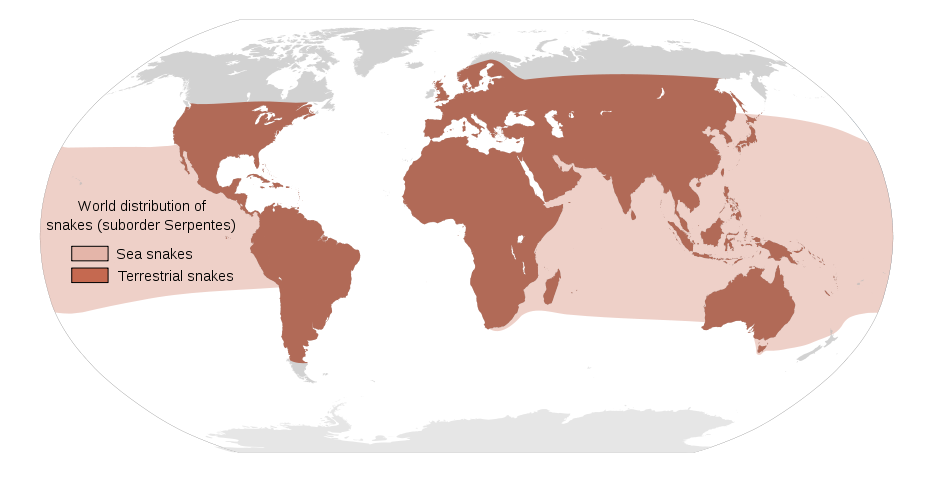

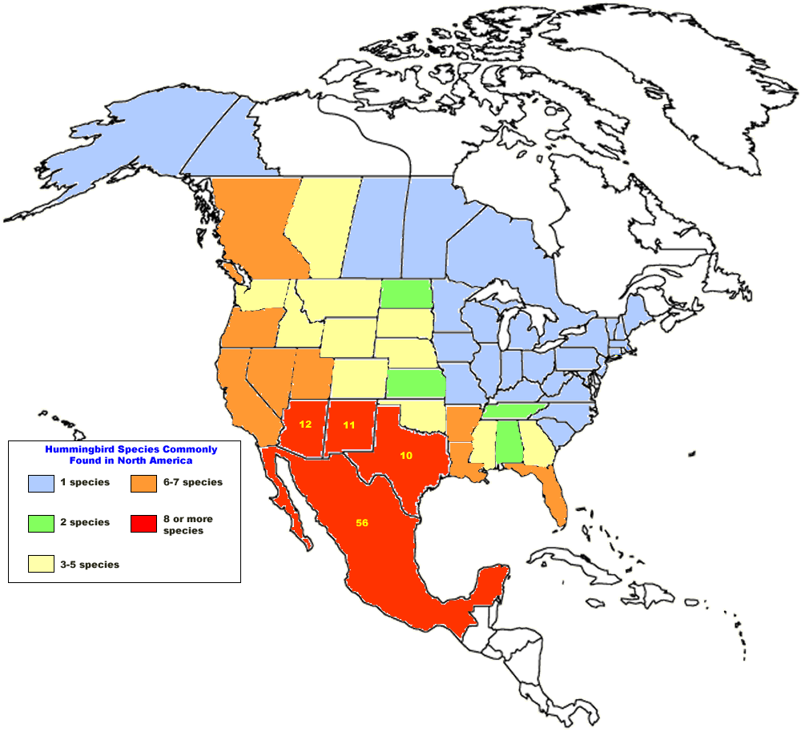

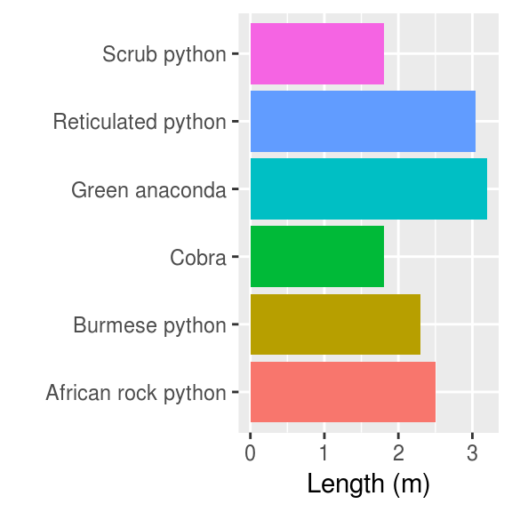

#### Experiment 2: Pre/Post Test protocol

Generate a set of ~10 topics, with corresponding images, graphs, and paragraphs of text.

Experiment Steps (participant perspective): 1. Pre-test assessment of their knowledge of each topic 2. Presented with text, images, or graphs plus a factual statement 3. Post-test assessment of their knowledge of each topic

In this experiment, we measure the change in the assessment of the veracity of a claim before and after presentation of additional corroborating information. Repetition is known to increase the perception of truth, so we would expect a priori that the “truthiness” of the post-test assessment is higher than that of the pre-test assessment. This effect may be mitigated by embedding the target statement in a set of several other statements, so that the repetition effect can be separated from the truthiness effect.

We will not be able to fully separate the effect of textual information, images, and data graphics, as data graphics and images will require some basic textual information as well; however, we can have a short text passage combined with an image or graph, or a long text passage.

In addition, by embedding one target question in a bank of several questions, each stimulus tested can provide data about relevant and not-relevant information. For example,

Pre-test statements:

1. (T/F) The Mona Lisa has no eyebrows
2. (T/F) The hummingbird is the bird that lays the largest egg in relation to its own size
3. (T/F) Turtles are deaf (TRUE CONTROL)
4. (T/F) The color green has the longest wavelength in the visible light spectrum (FALSE CONTROL)
5. (T/F) The cat is the only common pet not mentioned in the bible
6. (T/F) Cactuses can reproduce by parthenogenesis
7. (T/F) Starfish have no brains (TARGET)
8. (T/F) Your hands contain a quarter of the bones in your body

(Odd questions are true, even questions are false)

Example:

Short Text (No information provided about claim):

> Starfish or sea stars are star-shaped echinoderms belonging to the class Asteroidea. Common usage frequently finds these names being also applied to ophiuroids, which are correctly referred to as brittle stars or “basket stars”. About 1,500 species of starfish occur on the seabed in all the world’s oceans, from the tropics to frigid polar waters. They are found from the intertidal zone down to abyssal depths, 6,000 m (20,000 ft) below the surface.

> Starfish are marine invertebrates. They typically have a central disc and five arms, though some species have a larger number of arms. The aboral or upper surface may be smooth, granular or spiny, and is covered with overlapping plates. Many species are brightly coloured in various shades of red or orange, while others are blue, grey or brown. Starfish have tube feet operated by a hydraulic system and a mouth at the centre of the oral or lower surface. They are opportunistic feeders and are mostly predators on benthic invertebrates. Several species have specialized feeding behaviours including eversion of their stomachs and suspension feeding. They have complex life cycles and can reproduce both sexually and asexually. Most can regenerate damaged parts or lost arms and they can shed arms as a means of defence.

Supporting Text (No information provided about claim):

> Sea stars play a vital ecological role as top level predators shaping nearshore ecosystems. The absence of sea stars can enable other organisms that sea stars eat, like mussels, to multiply and drive out other nearshore inhabitants. An epidemic wasting disease, caused by a virus (Hewson et al. 2014) began in 2013, affecting sea stars from Alaska to Baja California, Mexico. A recent paper suggests that warmer water temperatures in the Pacific Ocean could have increased the spread of the disease and the high rates of sea star death in Washington State (Eisenlord et al. 2016).

> The epidemic affects at least 20 sea star species, and sea star populations along the west coast of the U.S. have experienced very high levels of death. As the disease progresses, sea stars often lose arms and can have a jelly-like appearance. Death can occur within a few days of the initial signs of infection. This disease has been observed in several locations in southeast Alaska, and more recently in Western Prince William Sound and Kachemak Bay.

Supporting Picture (No information provided about claim):  
Sea stars with a viral wasting disease.

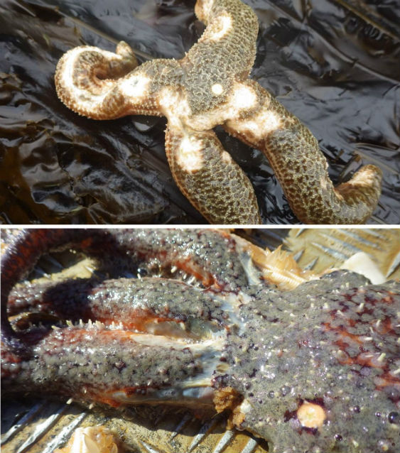

Supporting Graph (No information provided about claim):  
Decline of sea star populations in Southeast Alaska

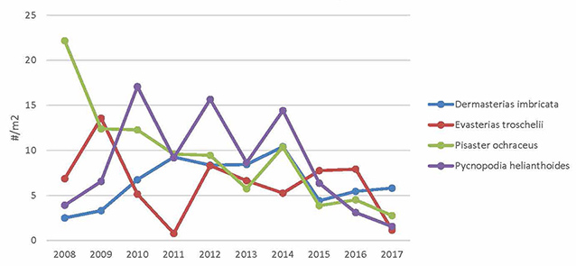

In the text-only condition, both the short Text and supporting text will be provided. In the text + picture condition, the supporting text + picture will be provided. In the text + graph condition, the supporting text + graph will be provided.

In all 3 conditions, the information provided does not “give away” the answer to the truth claim, but does relate to the topic enough to provide activation of the facts the participant already knows.

Post-test statements:

1. (T/F) The electric chair was invented by an accountant
2. (T/F) Starfish have no brains (TARGET)
3. (T/F) Macadamia nuts are in the same evolutionary family as peaches
4. (T/F) Turtles are deaf (TRUE CONTROL)
5. (T/F) The color green has the longest wavelength in the visible light spectrum (FALSE CONTROL)
6. (T/F) The 13th falls on a Friday when months begin with a Sunday
7. (T/F) Dogs have better memories than cats
8. (T/F) The Russian space station MIR means Peace

(Even statements are true)

The same set of pre/post test statements can be used with accompanying information about turtles, starfish, or the visible light spectrum, with the unmentioned topics serving as controls for the mentioned topic; the difference in the percentage of True answers for the control topics serves as an estimate of the repetition bias.

# References

Fenn, Elise, Eryn J Newman, Kathy Pezdek, and Maryanne Garry. 2013. “The Effect of Nonprobative Photographs on Truthiness Persists over Time.” *Acta Psychologica* 144 (1). Elsevier: 207–11.

Kellermann, Kathy. 2013. “Trial Advocacy: Truthiness, Falsiness, and Nothingness.” *Jury Expert* 25. HeinOnline: 38.

McCabe, David P, and Alan D Castel. 2008. “Seeing Is Believing: The Effect of Brain Images on Judgments of Scientific Reasoning.” *Cognition* 107 (1). Elsevier: 343–52.

Newman, Eryn J, Maryanne Garry, Daniel M Bernstein, Justin Kantner, and D Stephen Lindsay. 2012. “Nonprobative Photographs (or Words) Inflate Truthiness.” *Psychonomic Bulletin & Review* 19 (5). Springer: 969–74.